Review

Efficacy of Vitamin C Supplementation on

Collagen Synthesis and Oxidative Stress

After Musculoskeletal Injuries

A Systematic Review

Nicholas N. DePhillipo,*†MS, ATC, CSCS, Zachary S. Aman,†BA, Mitchell I. Kennedy,†BS,

J.P. Begley,* MD, Gilbert Moatshe,<sup>†‡§</sup>MD, PhD, and Robert F. LaPrade,*†<sup>k</sup>MD, PhD

Investigation performed at the Steadman Philippon Research Institute, Vail, Colorado, USA

Background: Recent investigations on the biochemical pathways after a musculoskeletal injury have suggested that vitamin C

(ascorbic acid) may be a viable supplement to enhance collagen synthesis and soft tissue healing.

Purpose: To (1) summarize vitamin C treatment protocols; (2) report on the efficacy of vitamin C in accelerating healing after bone,

tendon, and ligament injuries in vivo and in vitro; and (3) report on the efficacy of vitamin C as an antioxidant protecting against

fibrosis and promoting collagen synthesis.

Study Design: Systematic review; Level of evidence, 2.

Methods: A systematic review was performed, with the inclusion criteria of animal and human studies on vitamin C supple-

mentation after a musculoskeletal injury specific to collagen cross-linking, collagen synthesis, and biologic healing of the bone,

ligament, and tendon.

Results: The initial search yielded 286 articles. After applying the inclusion and exclusion criteria, 10 articles were included in the

final analysis. Of the preclinical studies evaluating fracture healing, 2 studies reported significantly accelerated bone healing in the

preclinical study after anterior cruciate ligament (ACL) reconstruction reported significant short-term (1-6 weeks) improvements in

ACL graft incorporation in the vitamin C group compared with control groups; however, there was no long-term (42 weeks) dif-

ference. Of the clinical studies evaluating fracture healing, 1 study reported no significant differences in the rate of fracture healing

at 50 days or functional outcomes at 1 year. Vitamin C supplementation was shown to decrease oxidative stress parameters by

neutralizing reactive oxygen species through redox modulation in animal models. No animal or human studies reported any

adverse effects of vitamin C supplementation.

Conclusion: Preclinical studies demonstrated that vitamin C has the potential to accelerate bone healing after a fracture, increase

type I collagen synthesis, and reduce oxidative stress parameters. No adverse effects were reported with vitamin C supple-

mentation in either animal models or human participants; thus, oral vitamin C appears to be a safe supplement but lacks clinical

evidence compared with controls. Because of the limited number of human studies, further clinical investigations are needed

before the implementation of vitamin C as a postinjury supplement.

Keywords: ascorbic acid; collagen synthesis; fracture healing; ACL reconstruction; collagen cross-linking; oxidative stress

The healing of musculoskeletal tissues, such as bone, ten-

dons, and ligaments, is dependent on the capacity of colla-

gen synthesis and cross-linking.<sup>7,20,34</sup>Poorly developed

extracellular matrices derived from collagen can lead to

inadequate tissue structures and biomechanical strength,

which can result in unsatisfactory outcomes and an

increased risk for reinjuries. Basic science investigations

on the biochemical pathways after a musculoskeletal

injury have suggested that vitamin C, also known as

ascorbic acid, may enhance collagen synthesis and soft

tissue healing.<sup>22,24,28,31</sup>

Vitamin C has an essential role in connective tissue heal-

ing, being a cofactor for prolyl hydroxylase and lysyl hydrox-

ylase.<sup>22,28</sup>These enzymes catalyze the hydroxylation of

proline and lysine residues of procollagen, promoting the

proper folding of the stable collagen triple-helix conforma-

tion.<sup>9,22</sup>In addition to its role in collagen synthesis, vitamin

C acts as a powerful antioxidant by neutralizing deleterious

reactive oxygen species (ROS) responsible for cell apoptosis

during the inflammatory phase.<sup>1,14,16</sup>Cell culture studies

have also reported that vitamin C can induce tendon-

derived stem cell mobilization, osteoblast growth and

differentiation, and fibroblast stimulation.<sup>8,11,18,21,26</sup>

Therefore, vitamin C has been increasingly studied for its

contributions to the treatment of musculoskeletal injuries

in both clinical and in vitro trials.

Although laboratory studies have reported that vitamin

C is essential for the formation of collagen fibers and cell

differentiation, there is controversy surrounding the effi-

cacy of vitamin C as a supplement for clinical treatment.

Therefore, the purposes of this systematic review were to

(1) summarize vitamin C treatment protocols; (2) report on

the efficacy of vitamin C in accelerating healing after bone,

tendon, and ligament injuries in vivo and in vitro; and (3)

report on the efficacy of vitamin C as an antioxidant pro-

tecting against fibrosis and promoting collagen synthesis.

It was hypothesized that vitamin C supplementation would

result in reduced oxidative stress and accelerated tissue

healing when compared with control groups.

METHODS

Article Identification and Selection

A systematic review of articles, using the PRISMA (Pre-

ferred Reporting Items for Systematic Meta-Analyses)

guidelines, on the efficacy of vitamin C in promoting colla-

gen synthesis, reducing inflammation, and improving bone/

ligament/tendon healing after musculoskeletal injuries was

performed using the Cochrane Database of Systematic

Reviews, the Cochrane Central Register of Controlled

Trials, PubMed (1980-2017), MEDLINE (1980-2017), and

Embase (1980-2017); the queries were performed in

November 2017. Registration of this systematic review was

performed in January 2018 using the PROSPERO interna-

tional

prospective

register

of

systematic

reviews

(CRD42018086378). The search terms utilized were

“vitamin C” OR “ascorbic acid” AND “musculoskeletal

injury”; “vitamin C” OR “ascorbic acid” AND “collagen

cross-linking”; “vitamin C” OR “ascorbic acid” AND

“orthopaedics”; “vitamin C” OR “ascorbic acid” AND “bone

healing”; “vitamin C” OR “ascorbic acid” AND “ligament

healing”; “vitamin C” OR “ascorbic acid” AND “tendon

healing”; and “vitamin C” OR “ascorbic acid” AND

“postoperative recovery.”

The inclusion criteria consisted of English-language

studies and both animal and human studies on vitamin C

supplementation after musculoskeletal injuries specific to

collagen cross-linking, collagen synthesis, and biologic

healing of the bone, ligament, and tendon. Exclusion

criteria were vitamin C supplementation specific to

nonmusculoskeletal-related injuries or surgery, healthy/

noninjured populations, scurvy, vitamin C deficiency, effect

of vitamin C on mesenchymal stem cells, genetic studies,

cellular studies, epidemiological studies, dietary intake

without vitamin C supplementation, editorial articles,

review articles, case reports (level 5 evidence), and surveys.

Two investigators (N.N.D., Z.S.A.) independently reviewed

the abstracts from all identified articles. If necessary, full-

text articles were obtained for a review to allow for further

application of inclusion and exclusion criteria. Addition-

ally, reference lists from the included studies were

reviewed and reconciled to verify that all eligible articles

were considered.

Data Collection

Both animal and human studies were collected. These find-

ings included experimental focus, abnormality, animal

model type, collagen type (ie, bone, ligament, tendon),

treatments, postoperative restrictions, route of vitamin C

administration, and vitamin C dosage (including frequency

and duration). The level of evidence of all available clinical

studies was assigned according to the classification as spec-

ified by Wright et al.<sup>38</sup>Patient demographics, supplemen-

tation dosage, treatment details, follow-up, and subjective

and objective patient outcomes were recorded for all clinical

studies. For continuous variables (age, outcome scores, etc),

the mean and range were obtained if reported.

RESULTS

The literature search identified 286 studies from the afore-

mentioned databases. After duplicates were removed, 264

articles were screened, and 10 articles met the inclusion

criteria (Figure 1). There were 7 studies that evaluated the

effects of vitamin C supplementation in animal models: 4

after bone fractures (nonoperative treatment), 2 after ten-

don ruptures (nonoperative and surgical treatment), and 1

after anterior cruciate ligament (ACL) reconstruction

(ACLR) (Table 1). Six of the animal studies used a rat

model, and 1 study used a chicken model. There were 3

studies

that

evaluated

the

effects

of

vitamin

C

kAddress correspondence to Robert F. LaPrade, MD, PhD, The Steadman Clinic, 181 West Meadow Drive, Suite 400, Vail, CO 81657, USA (email:

drlaprade@sprivail.org).

*The Steadman Clinic, Vail, Colorado, USA.

†Steadman Philippon Research Institute, Vail, Colorado, USA.

‡Oslo University Hospital, Oslo, Norway.

§OSTRC, Norwegian School of Sports Science, Oslo, Norway.

One or more of the authors has declared the following potential conflict of interest or source of funding: R.F.L. is a consultant for and receives royalties

from Arthrex, Ossur, and Smith & Nephew. AOSSM checks author disclosures against the Open Payments Database (OPD). AOSSM has not conducted an

independent investigation on the OPD and disclaims any liability or responsibility relating thereto.

supplementation in human models: 1 after ACLR and 2

after bone fractures (nonoperative and surgical treatment).

Two of the clinical studies were level 1 evidence, while 1

study was level 2 evidence.

Preclinical Studies

Vitamin C Dosage. Four studies determined vitamin C

dosage as a function of animal weight, ranging from 0.5 mg/

kg to 500 mg/kg.<sup>5,15,33,41</sup>The remaining 3 studies applied

standard doses between 0.005 mg and 150 mg.<sup>10,19,25</sup>The

delivery of vitamin C varied, including intraperitoneally

(n ¼ 4),<sup>5,15,25,33</sup>locally (n ¼ 1),<sup>19</sup>intramuscularly (n ¼

1),<sup>41</sup>or by intraoperative irrigation (n ¼ 1).<sup>10</sup>The interven-

tion was initiated on postinjury day 0 in all preclinical stud-

ies (n ¼ 7). The frequency of vitamin C dosage varied

between once at the time of injury to once per day until the

end of the trial. The duration of individual trials ranged

from 3 days to 6 weeks. Four studies allowed free access

to standard diet and water,<sup>5,25,33,41</sup>1 study provided a diet

that did not contain vitamin C,<sup>15</sup>and 2 studies did not

report food and water restrictions.<sup>10,19</sup>Five studies allowed

animals to move freely without immobilization after the pro-

cedure,<sup>10,15,25,33,41</sup>1 study immobilized the injured limb,<sup>19</sup>

and 1 study did not report on immobilization<sup>5</sup>(Table 2).

Efficacy of Vitamin C on Collagen Synthesis and Tissue

Healing. Overall, the preclinical studies supported the use

of vitamin C for tendon, bone, and ligament graft healing.

Three of the 4 studies evaluating the effects of vitamin C on

fracture healing reported an increase or acceleration in col-

lagen synthesis when compared with control groups.<sup>5,33,41</sup>

One study reported that there were no significant histolog-

ical or histomorphological score differences between the

vitamin C and control groups for fracture healing.<sup>15</sup>Both

studies evaluating tendon healing after ruptures reported

improved structural quality with vitamin C supplementa-

tion.<sup>19,25</sup>Omeroglu et al<sup>25</sup>reported that there was a signif-

et al<sup>19</sup>reported similar structural integrity in tendons, as

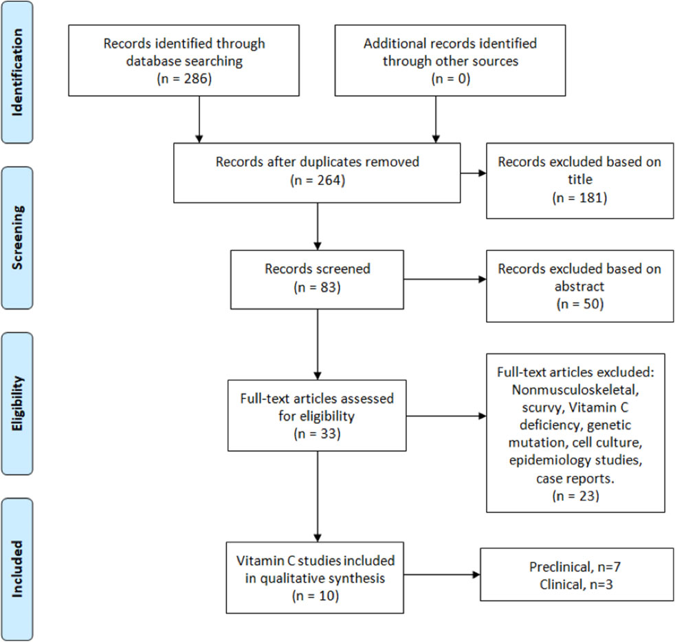

Figure 1. PRISMA (Preferred Reporting Items for Systematic Reviews and Meta-Analyses) flowchart showing the selection criteria

used to identify studies with the search strategy.

vitamin C significantly reduced the fibrotic size and peri-

tendinous adhesion. However, the authors did not report on

tendinous collagen composition.<sup>19</sup>Fu et al<sup>10</sup>reported that

low-dose vitamin C restored anteroposterior knee stability

and significantly reduced graft deterioration after ACLR

compared with the control group after 6 weeks; however,

there were no significant differences in long-term outcomes

(42 weeks) or ACL graft incorporation between groups. All

of the studies evaluating the role of vitamin C as an anti-

oxidant and collagen synthesizer (n ¼ 3) suggested that

vitamin C positively influences bone, tendon, and graft

healing by antagonizing oxidative stress.<sup>5,10,19</sup>No adverse

effects were reported in any preclinical study (n ¼ 7).

Efficacy of Vitamin C on the Reduction of Oxidative

Stress Parameters. Three preclinical studies<sup>5,10,19</sup>evalu-

ated oxidative stress after vitamin C supplementation. All

3 preclinical studies reported that vitamin C was effective

in reducing oxidative stress after injuries by decreasing

endogenous or exogenous ROS, signified by an improved

tissue composition in ligaments, tendons, and bone. How-

ever, only 1 of the 3 studies reported vitamin C as an antag-

onist for oxidative stress after 2 weeks.<sup>19</sup>Furthermore, 1

clinical study evaluated oxidative stress and muscle recov-

ery after vitamin C and E supplementation after ACLR.<sup>2</sup>

The authors reported that vitamin C and E supplementa-

tion had no significant effects on oxidative stress para-

meters compared with controls after ACLR.<sup>2</sup>

Clinical Studies

Patient Demographics and Vitamin C Dosage. The

patient demographics, study design, and experimental

focus of all clinical studies are reported in Table 3. Of the

3 clinical studies, 2 studies evaluated a combined supple-

ment of vitamin C and other antioxidants,<sup>2,32</sup>while 1 study

evaluated exclusively the effects of vitamin C.<sup>6</sup>The dosage

TABLE 1

Preclinical Studies: Demographics, Study Design, and Experimental Focus

Study

Study Design

(Level of Evidence)

Participants

Abnormality

Experimental Groups

Experimental

Focus

Omeroglu et al<sup>25</sup>

(2009)

Randomized

controlled

trial (level 1)

Female, nonpregnant,

albino Wistar rats

(N ¼ 42)

Achilles tendon

rupture

(1) Vitamin C (n ¼ 21) and (2)

control (n ¼ 21) with subgroups

(3rd day, 10th day, and 21st day

[n ¼ 7 each])

Tendon healing

Sarisozen et al<sup>33</sup>

(2002)

Randomized

controlled trial

(level 1)

Sprague-Dawley rats

(N ¼ 48)

Tibial fracture

(1) Vitamin E only (n ¼ 12), (2)

vitamin C only (n ¼ 12), (3)

vitamin C and E (n ¼ 12), and

(4) no treatment (n ¼ 12)

Bone healing

Hung et al<sup>19</sup>

(2013)

Controlled trial

(level 2)

Female Kamei

chickens (N ¼ 57)

Flexor digitorum

profundus

tendon tear

Part 1: (1) Operated (n ¼ 9) with

subgroups (day 0, 2 weeks, and

6 weeks [n ¼ 3 each]) and

(2) sham (n ¼ 3) with subgroups

(day 0, 2 weeks, and 6 weeks

[n ¼ 1 each])

Part 2: (1) 5 mg/mL of vitamin C

(n ¼ 12), (2) 50 mg/mL of

vitamin C (n ¼ 12), and

(3) control (n ¼ 12)

Reduction of

tendon adhesion

by antagonizing

oxidative stress

Giordano et al<sup>15</sup>

(2012)

Controlled trial

(level 2)

Male Wistar rats

(N ¼ 30)

Tibial fracture

(1) Vitamin C (n ¼ 15) and

(2) control (n ¼ 15)

Bone healing and

effect on

osteogenesis

Duygulu et al<sup>5</sup>

(2007)

Randomized

controlled trial

(level 1)

Male, albino Wistar

rats (N ¼ 50)

Radial and ulnar

fracture

(1) Control (n ¼ 10), (2) zymosan

only (n ¼ 10), (3) zymosan þ

DMSO (n ¼ 10), (4) zymosan þ

EGb 761 (n ¼ 10), and (5)

zymosan þ vitamin C (n ¼ 10)

Effect of oxidative

stress and

protective effect

of antioxidants

on bone healing

Yilmaz et al<sup>41</sup>

(2001)

Randomized

controlled trial

(level 1)

Albino Wistar rats

(N ¼ 16)

Tibial fracture

(1) Control (n ¼ 8) and (2) vitamin

C (n ¼ 8)

Bone healing

Fu et al<sup>10</sup>(2013)

Controlled trial

(level 2)

Male Sprague-Dawley

rats (N ¼ 114)

Anterior cruciate

ligament tear

Part 1: (1) Control (n ¼ 26), (2)

3 mg/mL of vitamin C (n ¼ 26),

(3) 10 mg/mL of vitamin C

(n ¼ 26), and (4) 30 mg/mL of

vitamin C (n ¼ 26) with

subgroups (day 1, day 2, day 3,

and week 6 [n ¼ 4 each])

Part 2: (1) Sham (n ¼ 10) and (2)

operated (n ¼ 10)

Ligament graft

healing and

reduction of

C-reactive

protein plasma

levels

TABLE 2

Preclinical Studies: Treatment Protocols After Musculoskeletal Injuries<sup>a</sup>

Study

Treatment and

Restrictions

Route of

Exposure

Dosage

Frequency

Duration

Conditions

Results

Conclusion

Omeroglu

et al<sup>25</sup>

(2009)

None;

weightbearing

without

immobilization

Intraperitoneally 150 mg vitamin

C (1.5 mL)

Once on day of

injury and

then once

every 2 days

3 days, 10 days,

and 21 days

Allowed to move

freely in cages

with free

access to food

and water

Significant difference in type I

collagen production on

10th day, mean collagen

fiber diameter and active

fibroblasts higher in

vitamin C group, and more

evident angiogenesis on

3rd day

irrigation may be of

potential use to promote

healing

Sarisozen

et al<sup>33</sup>

(2002)

None;

weightbearing

without

immobilization

Intraperitoneally 200 mg/kg

vitamin C

Once per day

for 3 days

and then

3 times per

week

14 days and

21 days

Free access to

food and water

Vitamin C group had

accelerated bone matrix

mineralization and

increased amount of

collagen

Vitamin C supplementation

accelerated fracture

healing

Hung

et al<sup>19</sup>

(2013)

Tendon repair;

immobilization

for 2 weeks

Local injection

5 mg/mL or

50 mg/mL

vitamin C

(50 mL total

volume)

Once

2 weeks and

6 weeks

N/A

No significant difference at

2 weeks between groups,

significant improvement

in gliding resistance at 6

weeks in vitamin C group,

5 mg/mL of vitamin C had

significant reduction in

fibrotic size at 6 weeks

compared with control

group, and less

peritendinous adhesion in

vitamin C group

Local injection of vitamin C

solution can reduce extent

of tendon adhesion after

tendon repair

Giordano

et al<sup>15</sup>

(2012)

None;

weightbearing

without

immobilization

Intraperitoneally 200 mg/kg

vitamin C

Once per day

2 weeks,

4 weeks,

and 6 weeks

Caged with access

to water and

standard feed

ad libitum

containing no

vitamin C

No significant histological

or histomorphological

differences

Vitamin C supplementation

did not accelerate fracture

healing process

Duygulu

et al<sup>5</sup>

(2007)

None; N/A

Intraperitoneally 500 mg/kg

vitamin C

(þ 100 mg/kg

zymosan per

day for first

5 days)

Once per day

21 days

Caged laboratory

conditions

with standard

diet and water

Oxidative stress impaired

bone healing;

histopathological,

radiographic (bony union),

and electromyographic

(collagen fibrils)

evaluations for vitamin C

group were similar to that

of control group; and

significant difference in

zymosan-only group for

improved fracture healing

Free oxygen radicals have

role in disruption of

fracture healing, and

vitamin C can partially

prevent negative effects

Yilmaz

et al<sup>41</sup>

(2001)

None;

weightbearing

Intramuscularly

0.5 mg/kg

vitamin C

Once

5 days, 10 days,

15 days, and

20 days

Caged with rat

food,

unlimited

access to

water, and

unrestricted

activity

No significant difference

between groups overall;

and vitamin C group was

faster in chondroid cell

development, chondrocyte

hypertrophy, and

fibrocartilaginous callus

development than control

group (P > .05)

Although there was no

difference in quality of

fracture healing, vitamin

C–supplemented group

was faster in healing

process compared with

controls

Fu et al<sup>10</sup>

(2013)

ACL reconstruction;

weightbearing

without

immobilization

Intraoperative

irrigation

solution

3 mg/mL,

10 mg/mL,

or 30 mg/mL

(10 mL)

vitamin C

Once

1 day, 4 days,

7 days, and

6 weeks

Caged

Vitamin C group had

significantly reduced

serum C-reactive protein

levels at day 1, 3 mg/mL of

vitamin C led to better

restoration of

anteroposterior knee

stability at 6 weeks

compared with control

group, 3 and 10 mg/mL of

vitamin C significantly

reduced graft deterioration

at 6 weeks, and no

significant difference

between groups at 42

weeks for graft

incorporation

Low dose of vitamin C

demonstrated short-term

improvements after ACL

reconstruction compared

with controls, but there

were no significant

differences in ACL graft

incorporation between

groups

aThe intervention was initiated on postinjury day 0 in all studies (n ¼ 7). ACL, anterior cruciate ligament; N/A, not available.

of orally supplemented vitamin C ranged from 60 mg twice

daily to 500 mg twice daily for a minimum of 7 days and

maximum of 3 months. The 2 studies evaluating bone frac-

ture healing began vitamin C supplementation on day 1

after the fracture.<sup>6,32</sup>The study evaluating oxidative stress

and muscle recovery began vitamin C supplementation 2

weeks before the planned ACLR.<sup>2</sup>

Clinical Outcomes. The clinical trial evaluating muscle

recovery after ACLR reported no significant differences

between the vitamin C and control groups.<sup>2</sup>However, base-

line vitamin C status was associated with significant

improvements in strength, suggesting that long-term die-

tary habits may be more effective than short-term supple-

ments.<sup>2</sup>The results of the 2 clinical trials evaluating bone

healing after fractures were conflicting. Sandukji et al<sup>32</sup>

reported significant increases in osteocalcin levels and the

activity of alkaline phosphatase in the blood plasma of

patients who received antioxidants for 2 weeks (P < .05),

both of which are bone markers previously reported to be

positively correlated with bone mineral density (BMD).<sup>13,35</sup>

However, these authors did not report on the long-term

results of fracture healing. In contrast, Ekrol et al<sup>6</sup>noted

no significant difference in the time to fracture healing in

patients with long bone fractures who were supplemented

with vitamin C compared with controls. Furthermore, there

were no significant differences between the 2 treatment

groups at 1-year follow-up.<sup>6</sup>No adverse effects were reported

in any clinical study (n ¼ 3) regarding the use of vitamin C,

and 1 study reported a dropout rate of 26% and a compliance

rate of 84%.<sup>6</sup>Despite this high dropout rate, the authors still

managed to include a large sample size (n ¼ 162) in their

final analysis.<sup>6</sup>Further results are detailed in Table 4.

DISCUSSION

The most important finding of this systematic review was

that there is preclinical evidence that vitamin C supple-

mentation accelerates bone healing after fractures,

increases type I collagen synthesis, and reduces oxidative

stress parameters (detailed in Figure 2). However, clinical

evidence does not replicate the results seen in animal mod-

els to date. Furthermore, high doses (ie, �1000 mg/d) of

orally administered vitamin C had no direct benefit com-

pared with controls. Conversely, low doses (ie, 60 mg/d) of

orally administered vitamin C had a significant difference

of increased bone biomarkers compared with controls.

Overall, there are limited data regarding the efficacy of

vitamin C supplementation after musculoskeletal injuries.

No adverse effects were reported with vitamin C supple-

mentation in either animal models or human participants.

After a musculoskeletal injury, the activation of inflam-

matory cells has been observed to overproduce ROS, caus-

ing deleterious oxidative stress. Oxidative stress has been

described as an imbalance between ROS and antioxi-

dants,<sup>19</sup>resulting in a hostile healing environment that

negatively affects the viability and proliferation of

recruited collagen-producing cells and ultimately promot-

ing apoptosis.<sup>14,16,17,21</sup>Vitamin C as an antioxidant is capa-

ble of neutralizing ROS through redox reactions, relieving

oxidative stress due to inflammation. All 3 preclinical stud-

ies evaluating oxidative stress reported that vitamin C was

effective in reducing oxidative stress after injuries by

decreasing endogenous or exogenous ROS, signified by an

improved tissue composition in ligaments, tendons, and

bone.<sup>5,10,19</sup>However, only 1 of the 3 studies reported vita-

min C as an antagonist for oxidative stress after 2 weeks,<sup>19</sup>

limiting preclinical support for the clinical implications as a

postinjury supplement.

Four of 5 studies investigating the effects of vitamin C on

collagen production suggested that vitamin C was effective

by stimulating biochemical pathways associated with colla-

gen synthesis. Omeroglu et al<sup>25</sup>reported that vitamin C

increased the activity for procollagen-secreting fibroblasts

and overall type I collagen production. The stimulation of

collagen-producing cells was also reported by Yilmaz

et al,<sup>41</sup>who observed accelerated rates of chondrocyte

development and hypertrophy. Sandukji et al<sup>32</sup>reported

elevations in alkaline phosphatase, a vitamin C–dependent

TABLE 3

Clinical Studies: Demographics, Study Design, and Experimental Focus

Study

Study Design

(Level of

Evidence)

Participants

Abnormality

Experimental Groups

Experimental

Focus

Barker et al<sup>2</sup>

(2009)

Randomized

controlled

trial (level 1)

Male with preoperative/

postoperative

supplementation

(N ¼ 20)

Anterior cruciate

ligament tear

(1) Vitamins C and E (n ¼ 10)

and (2) placebo (n ¼ 10)

Muscle atrophy/

recovery and

oxidative stress

parameters

Ekrol et al<sup>6</sup>

(2014)

Controlled trial

(level 2)

Male and female with

postinjury

supplementation

(N ¼ 336)

Distal radius fracture

Displaced fractures: (1) Vitamin

C (n ¼ 94) and (2) placebo

(n ¼ 92)

Nondisplaced fractures: (1)

Vitamin C (n ¼ 75) and (2)

placebo (n ¼ 75)

Bone healing

Sandukji

et al<sup>32</sup>

(2011)

Randomized

controlled

trial (level 1)

Male with postoperative

supplementation

(N ¼ 55)

Long bone fracture

(humerus, radius,

ulna, tibia, femur)

(1) Vitamins A, C, and E and

selenium (n ¼ 20) and (2)

control (n ¼ 35)

Bone healing and

oxidative stress

parameters

enzyme involved in osteoblastic differentiation and bone

formation.<sup>8,11,18,26</sup>Sarisozen et al<sup>33</sup>also suggested that the

observed increase in callus formation due to vitamin C

resulted from osteoblast proliferation, although cellular

activity was not quantified. Overall, these studies provide

evidence that vitamin C may be effective in promoting col-

lagen synthesis in vivo, although further clinical studies

are needed to strengthen the implications for postoperative

vitamin C supplementation.

Barker et al<sup>2</sup>reported that vitamin C and E supplemen-

tation was ineffective in potentiating the improvement in

force production of the injured limb after ACLR. However,

baseline vitamin C status was associated with beneficial

outcomes in strength, suggesting that long-term dietary

habits may be more effective than short-term supplements.

Ligamentous integrity at follow-up (3 months postopera-

tively) was not examined<sup>2</sup>; thus, collagen synthesis and lig-

ament healing with vitamin C supplementation have not

been investigated clinically in the current literature.

Ekrol et al<sup>6</sup>found no significant difference in functional

outcomes at 1 year between patients treated with vitamin C

TABLE 4

Clinical Studies: Treatment Protocols After Musculoskeletal Injuries<sup>a</sup>

Study

Treatment and

Restrictions

Start of

Vitamin C

Route of

Exposure

Dosage

Frequency

Duration

Conditions

Results

Conclusion

Barker

et al<sup>2</sup>

(2009)

ACLR with double-

bundle hamstring

autograft (n ¼ 19

[95%]) and bone–

patellar tendon–

bone autograft

(n ¼ 1 [5%]);

nonweightbearing

for 5 days (n ¼ 20

[100%])

2 weeks

before

ACLR

Orally

500 mg vitamin C

and 200 IU

vitamin E

Twice

daily

3 months

Diet not restricted,

and restricted

NSAID use for

duration of

study

Significant increase in

peak isometric force of

injured limb in both

groups (P < .05),

vitamin C/E did not

augment strength

gains (P > .05), and

significant correlation

between baseline

vitamin C and

strength recovery

after ACLR (P < .05)

Vitamin E and C

supplementation was

ineffective in

augmenting

improvement in force

production by injured

limb; however,

baseline vitamin C

status was associated

with beneficial

outcomes in strength,

suggesting that long-

term dietary habits

are more effective

than short-term

supplements

Ekrol

et al<sup>6</sup>

(2014)

Surgical (displaced

fracture): open

reduction internal/

external fixation

(n ¼ 186 [55%])

Conservative

(nondisplaced

fracture): cast

(n ¼ 150 [45%])

Day 1 after

fracture

Orally

500 mg vitamin C

Daily

50 days

Diet not restricted

but monitored,

and excluded

patients

currently

taking vitamin

C before

fracture

Time to fracture healing

did not differ between

treatment groups

(P ¼ .42 and .23), and

no difference in

functional outcomes

at 1 year (P > .05)

No difference in DASH

score, other functional

outcomes, occurrence

of CRPS, or fracture

healing with vitamin

C treatment in

patients with distal

radius fracture

Sandukji

et al<sup>32</sup>

(2011)

Surgery: open

reduction internal

fixation (n ¼ 55

[100%])

Day 1 after

fracture

Orally and

intravenously

Groups 1/2: 300 mg

vitamin A, 10

mg vitamin E,

60 mg vitamin

C, and

75 mg selenium

Groups 3/4:

1000 mg/d

cephalosporin

for 3 days, 50

mg oral

diclofenac, and

500 mg

paracetamol

twice daily for

15 days

Twice

daily

Group 1: 7 days

Group 2: 15

days

Groups 3/4: 15

days

N/R

Osteocalcin level and

activity of alkaline

phosphatase were

markedly increased

in plasma of patients

who received

antioxidants for 2

weeks (P < .05), and

level of plasma

glutathione was

significantly

increased only after 2

weeks in patients who

received antioxidants

(P < .05)

Elevation of osteocalcin

levels might increase

BMD and thus could

accelerate healing of

bone fractures

because high levels of

osteocalcin and

alkaline phosphatase

are positively

correlated with BMD;

and antioxidant

vitamins A, C, and E

and selenium could

accelerate bone

healing after long-

bone fixation surgery

aStatistical significance was indicated at P < .05. ACLR, anterior cruciate ligament reconstruction; BMD, bone mineral density; CRPS, chronic

regional pain syndrome; DASH, Disabilities of the Arm, Shoulder and Hand; N/R, not reported; NSAID, nonsteroidal anti-inflammatory drug.

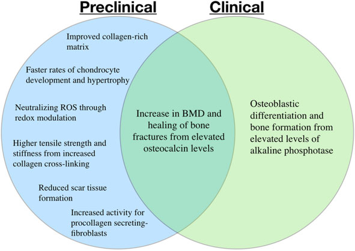

Figure 2. Reported effects of vitamin C supplementation after

musculoskeletal injuries according to preclinical and clinical

evidence. BMD, bone mineral density; ROS, reactive oxygen

species.

or a placebo after either a nondisplaced or displaced distal

radius fracture. Although other studies have suggested a

beneficial effect of vitamin C on fracture healing in animal

models, Ekrol and colleagues<sup>6</sup>found no difference in the

Disabilities of the Arm, Shoulder and Hand (DASH) score,

other functional outcomes, occurrence of chronic regional

pain syndrome, or fracture healing with vitamin C treat-

ment in patients with a distal radius fracture. It is impor-

tant to note that functional outcomes after a distal radius

fracture are also influenced by the condition of soft tissues

in addition to bone healing.

Sandukji et al<sup>32</sup>found that osteocalcin levels signifi-

cantly increased in the plasma of patients treated with vita-

min C for 2 weeks compared with those of the non–

antioxidant-treated group. An elevation of osteocalcin

levels might increase BMD and consequently could acceler-

ate healing of bone fractures because high levels of osteo-

calcin and alkaline phosphatase have been reported to be

positively correlated with BMD.<sup>12,23,37,39</sup>The authors con-

cluded that the administration of the antioxidant vitamins

A, E, and C, in addition to selenium, could accelerate bone

healing after long-bone fixation surgery; therefore, antiox-

idants could be considered in designing therapeutic proto-

cols for postoperative bone fracture surgery.<sup>32</sup>

Previous research has demonstrated that the intrave-

nous administration of vitamin C produces a plasma con-

centration 30- to 70-fold higher than the maximum

tolerated oral doses.<sup>27</sup>This suggests that high doses given

through intravenous administration may not be necessary,

if not deleterious to musculoskeletal healing. However, low

doses of vitamin C administered intravenously allows for

optimal bioavailability of the supplement, which may pro-

vide the means for musculoskeletal healing.<sup>4,27</sup>With

regard to supplementation after musculoskeletal injuries,

the majority of preclinical studies administering vitamin C

parenterally observed significant benefits in the rate of

healing and reduced oxidative stress parameters compared

with controls.<sup>5,10,19,25,33,41</sup>

vitamin C supplementation after musculoskeletal injuries

compared with controls. However, no current studies have

evaluated the efficacy of only vitamin C administered intra-

venously after musculoskeletal injuries. We recognize that

there is difficulty administering intravenous medications

over long durations and rather suggest that intravenous

vitamin C administration immediately postoperatively may

have beneficial effects on musculoskeletal healing. We

encourage future studies that attempt to delineate the

effects of intravenous vitamin C during these recovery per-

iods before intravenous doses can be recommended.

A complete understanding of the mechanism of action of

vitamin C remains unclear. Several basic science and clin-

ical studies investigating tumor development have reported

that the overexpression of antioxidant enzymes and high

doses of vitamin C (ie, �1000 mg/d) may impair wound

healing and angiogenesis.<sup>29,30,36,40</sup>Although high concen-

trations of ROS can be deleterious to tissue healing, low

concentrations of ROS have been demonstrated to promote

angiogenesis and mesenchymal stem cell proliferation.<sup>3</sup>

Therefore, it has been hypothesized that overscavenging

of ROS by vitamin C may impair healing in musculoskeletal

injury settings.<sup>19</sup>Sandukji et al<sup>32</sup>reported increased bio-

markers of bone with 60 mg/d of vitamin C, which provides

clinical evidence for the use of low doses of vitamin C as a

postinjury supplement. Therefore, we recommend that the

low-dose oral administration (ie, 60 mg/d) of vitamin C may

be an effective form of treatment after musculoskeletal

injuries. However, there are currently no definitive treat-

ment protocols for the administration of vitamin C. Further

clinical studies analyzing a broader range of oral doses, the

efficacy of vitamin C administration via parental routes,

and the synergistic actions of combined antioxidant admin-

istration are encouraged.

Limitations

We acknowledge some limitations to this systematic

review. Although vitamin C is a well-known supplement

that is used frequently, only 10 studies were included after

the specific inclusion criteria were applied, which reflects

the overall lack of evidence-based literature regarding vita-

min C supplementation after musculoskeletal injuries. The

heterogeneity in vitamin C supplementation protocols,

including the route of administration, dosage, frequency,

and duration, limits direct comparisons when evaluating

combined results. Furthermore, variations in the type of

collagen (bone, tendon, ligament) studied and the treat-

ment methods (conservative vs surgical) used limit the

global interpretation of results on vitamin C supplementa-

tion. One clinical study evaluated the effects of only vita-

min C supplementation, and 2 studies evaluated the effects

of the combined supplementation of vitamin C and other

antioxidants; this may affect the clinical findings and direct

interpretation of vitamin C. In addition, no clinical studies

evaluated the evidence for tendon healing after vitamin C

supplementation. Also, there were differences in the injury

location (ie, hand, wrist, knee), so the results may not be

generalizable to other injury locations in the body (ie,

shoulder, hip, ankle). In addition, because rats are capable

of synthesizing vitamin C through a normal diet, a function

that humans do not exhibit, this is a direct limitation of the

preclinical studies. It is suggested that further preclinical

studies be performed on animals that also do not contain

this trait, including chickens, guinea pigs, and primates,

which can isolate the effects of exogenous vitamin C.

CONCLUSION

Preclinical studies demonstrated that vitamin C has the

potential to accelerate bone healing after fractures,

increase type I collagen synthesis, and reduce oxidative

stress parameters. No adverse effects were reported with

vitamin C supplementation in either animal models or

human participants; thus, oral vitamin C appears to be a

safe supplement but lacks clinical evidence compared with

controls. Because of the limited number of human studies,

further clinical investigations are needed before the imple-

mentation of vitamin C as a postinjury supplement.

REFERENCES

1. Badr G, Hozzein WN, Badr BM, Al Ghamdi A, Saad Eldien HM, Gar-

raud O. Bee venom accelerates wound healing in diabetic mice by

suppressing activating transcription factor-3 (ATF-3) and inducible

nitric oxide synthase (iNOS)-mediated oxidative stress and recruiting

bone marrow-derived endothelial progenitor cells. J Cell Physiol.

2016;231(10):2159-2171.

2. Barker T, Leonard SW, Hansen J, et al. Vitamin E and C supplemen-

tation does not ameliorate muscle dysfunction after anterior cruciate

ligament surgery. Free Radic Biol Med. 2009;47(11):1611-1618.

3. Chan EC, Jiang F, Peshavariya HM, Dusting GJ. Regulation of cell

proliferation by NADPH oxidase-mediated signaling: potential roles in

tissue repair, regenerative medicine and tissue engineering. Pharma-

col Ther. 2009;122(2):97-108.

4. Duconge J, Miranda-Massari JR, Gonzalez MJ, Jackson JA, Warnock

W, Riordan NH. Pharmacokinetics of vitamin C: insights into the oral

and intravenous administration of ascorbate. P R Health Sci J. 2008;

27(1):7-19.

5. Duygulu F, Yakan B, Karaoglu S, Kutlubay R, Karahan OI, Ozturk A.

The effect of zymosan and the protective effect of various antioxi-

dants on fracture healing in rats. Arch Orthop Trauma Surg. 2007;

127(7):493-501.

6. Ekrol I, Duckworth AD, Ralston SH, Court-Brown CM, McQueen MM.

The influence of vitamin C on the outcome of distal radial fractures: a

double-blind, randomized controlled trial. J Bone Joint Surg Am.

2014;96(17):1451-1459.

7. Fazzalari NL, Forwood MR, Smith K, Manthey BA, Herreen P. Assess-

ment of cancellous bone quality in severe osteoarthrosis: bone min-

eral density, mechanics, and microdamage. Bone. 1998;22(4):

381-388.

8. Franceschi RT, Iyer BS, Cui Y. Effects of ascorbic acid on collagen

matrix formation and osteoblast differentiation in murine MC3T3-E1

cells. J Bone Miner Res. 1994;9(6):843-854.

9. Franceschi RT, Wilson JX, Dixon SJ. Requirement for Na(þ)-dependent

ascorbic acid transport in osteoblast function. Am J Physiol. 1995;

268(6 pt 1):C1430-C1439.

10. Fu SC, Cheng WH, Cheuk YC, et al. Development of vitamin C irriga-

tion saline to promote graft healing in anterior cruciate ligament

reconstruction. J Orthop Trans. 2013;1:67-77.

11. Ganta DR, McCarthy MB, Gronowicz GA. Ascorbic acid alters colla-

gen integrins in bone culture. Endocrinology. 1997;138(9):3606-3612.

12. Garnero P, Delmas PD. Contribution of bone mineral density and

bone turnover markers to the estimation of risk of osteoporotic frac-

ture in postmenopausal women. J Musculoskelet Neuronal Interact.

2004;4(1):50-63.

13. Garnero P, Delmas PD. Noninvasive techniques for assessing skeletal

changes in inflammatory arthritis: bone biomarkers. Curr Opin Rheu-

matol. 2004;16(4):428-434.

14. Garrett IR, Boyce BF, Oreffo RO, Bonewald L, Poser J, Mundy GR.

Oxygen-derived free radicals stimulate osteoclastic bone resorp-

tion in rodent bone in vitro and in vivo. J Clin Invest. 1990;85(3):

632-639.

15. Giordano V, Albuquerque RP, do Amaral NP, Chame CC, de Souza F,

Apfel MI. Supplementary vitamin C does not accelerate bone healing

in a rat tibia fracture model. Acta Ortop Bras. 2012;20(1):10-12.

16. Gokturk E, Turgut A, Baycu C, Gunal I, Seber S, Gulbas Z. Oxygen-

free radicals impair fracture healing in rats. Acta Orthop Scand. 1995;

66(5):473-475.

17. Haigler HJ, Spring DD. Comparison of the analgesic effects of

dimethyl sulfoxide and morphine. Ann N Y Acad Sci. 1983;411:19-27.

18. Harada S, Matsumoto T, Ogata E. Role of ascorbic acid in the regu-

lation of proliferation in osteoblast-like MC3T3-E1 cells. J Bone Miner

Res. 1991;6(9):903-908.

19. Hung LK, Fu SC, Lee YW, Mok TY, Chan KM. Local vitamin-C injec-

tion reduced tendon adhesion in a chicken model of flexor digitorum

profundus tendon injury. J Bone Joint Surg Am. 2013;95(7):e41.

20. Kjaer M, Langberg H, Heinemeier K, et al. From mechanical loading to

collagen synthesis, structural changes and function in human tendon.

Scand J Med Sci Sports. 2009;19(4):500-510.

21. Lee YW, Fu SC, Yeung MY, Lau CML, Chan KM, Hung LK. Effects of

redox modulation on cell proliferation, viability, and migration in cul-

tured rat and human tendon progenitor cells. Oxid Med Cell Longev.

2017;2017:8785042.

22. Manela-Azulay M, Bagatin E. Cosmeceuticals vitamins. Clin Derma-

tol. 2009;27(5):469-474.

23. Mimori K, Komaki M, Iwasaki K, Ishikawa I. Extracellular signal-

regulated kinase 1/2 is involved in ascorbic acid-induced osteoblastic

differentiation in periodontal ligament cells. J Periodontol. 2007;78(2):

328-334.

24. Murad S, Grove D, Lindberg KA, Reynolds G, Sivarajah A, Pinnell SR.

Regulation of collagen synthesis by ascorbic acid. Proc Natl Acad Sci

U S A. 1981;78(5):2879-2882.

25. Omeroglu S, Peker T, Turkozkan N, Omeroglu H. High-dose vitamin C

supplementation accelerates the Achilles tendon healing in healthy

rats. Arch Orthop Trauma Surg. 2009;129(2):281-286.

26. Otsuka E, Yamaguchi A, Hirose S, Hagiwara H. Characterization of

osteoblastic differentiation of stromal cell line ST2 that is induced by

ascorbic acid. Am J Physiol. 1999;277(1 pt 1):C132-C138.

27. Padayatty SJ, Sun H, Wang Y, et al. Vitamin C pharmacokinetics:

implications for oral and intravenous use. Ann Intern Med. 2004;

140(7):533-537.

28. Phillips CL, Combs SB, Pinnell SR. Effects of ascorbic acid on prolif-

eration and collagen synthesis in relation to the donor age of human

dermal fibroblasts. J Invest Dermatol. 1994;103(2):228-232.

29. Redondo P, Jimenez E, Perez A, Garcia-Foncillas J. N-acetylcysteine

downregulates vascular endothelial growth factor production by

human keratinocytes in vitro. Arch Dermatol Res. 2000;292(12):

621-628.

30. Roy S, Khanna S, Nallu K, Hunt TK, Sen CK. Dermal wound healing is

subject to redox control. Mol Ther. 2006;13(1):211-220.

31. Russell JE, Manske PR. Ascorbic acid requirement for optimal flexor

tendon repair in vitro. J Orthop Res. 1991;9(5):714-719.

32. Sandukji A, Al-Sawaf H, Mohamadin A, Alrashidi Y, Sheweita SA.

Oxidative stress and bone markers in plasma of patients with long-

bone fixative surgery: role of antioxidants. Hum Exp Toxicol. 2011;

30(6):435-442.

33. Sarisozen B, Durak K, Dincer G, Bilgen OF. The effects of vitamins E

and C on fracture healing in rats. J Int Med Res. 2002;30(3):309-313.

34. Shaw G, Lee-Barthel A, Ross ML, Wang B, Baar K. Vitamin

C-enriched gelatin supplementation before intermittent activity aug-

ments collagen synthesis. Am J Clin Nutr. 2017;105(1):136-143.

35. Taylor AK, Lueken SA, Libanati C, Baylink DJ. Biochemical markers of

bone turnover for the clinical assessment of bone metabolism. Rheum

Dis Clin North Am. 1994;20(3):589-607.

36. Verrax J, Calderon PB. Pharmacologic concentrations of ascorbate

are achieved by parenteral administration and exhibit antitumoral

effects. Free Radic Biol Med. 2009;47(1):32-40.

37. Weber P. The role of vitamins in the prevention of osteoporosis: a brief

status report. Int J Vitam Nutr Res. 1999;69(3):194-197.

38. Wright JG, Swiontkowski MF, Heckman JD. Introducing levels of evi-

dence to the journal. J Bone Joint Surg Am. 2003;85(1):1-3.

39. Wu X, Itoh N, Taniguchi T, et al. Zinc-induced sodium-dependent

vitamin C transporter 2 expression: potent roles in osteoblast differ-

entiation. Arch Biochem Biophys. 2003;420(1):114-120.

40. Yasuda M, Ohzeki Y, Shimizu S, et al. Stimulation of in vitro angio-

genesis by hydrogen peroxide and the relation with ETS-1 in endo-

thelial cells. Life Sci. 1999;64(4):249-258.

41. Yilmaz C, Erdemli E, Selek H, Kinik H, Arikan M, Erdemli B. The con-

tribution of vitamin C to healing of experimental fractures. Arch

Orthop Trauma Surg. 2001;121(7):426-428.